# Lab assignment: dogs VS cats

In this assignment we will face an image classification problem, trying to tell apart images of dogs and images of cats. The final battle begins! And to do so we will use a Deep Learning approach.

## Guidelines

Throughout this notebook you will find empty cells that you will need to fill with your own code. Follow the instructions in the notebook and pay special attention to the following symbols.

You will need to solve a question by writing your own code or answer in the cell immediately below or in a different file, as instructed.

This is a hint or useful observation that can help you solve this assignment. You should pay attention to these hints to better understand the assignment.

This is an advanced exercise that can help you gain a deeper knowledge into the topic. Good luck!

To avoid missing packages and compatibility issues you should run this notebook under one of the [recommended Deep Learning environment files](https://github.com/albarji/teaching-environments/tree/master/deeplearning).

The following code will embed any plots into the notebook instead of generating a new window:

```python
import matplotlib.pyplot as plt
%matplotlib inline
```

```python
#in this cell we import all the modules.
from skimage.transform import resize
import random
import cv2
import glob
import pickle
import glob
import inspect
import numpy as np
import keras
```

Lastly, if you need any help on the usage of a Python function you can place the writing cursor over its name and press Caps+Shift to produce a pop-out with related documentation. This will only work inside code cells.

Let's go!

## Data processing

The images to use in this assignment are available [here](https://drive.google.com/open?id=105jGDrjEgxx2W2gYhFF8Mbf1J9qJeDPm). Download the data package and extract it into a folder in your computer.

Data is structured under two folders, *train* and *test*. You are only allowed to use the *test* data to measure the performance of your model **after** you have finished training. Both *train* and *test* folders contain one subfolder per class (*cats* and *dogs*).

The recommended way to load an image from disk is to use the *imread* function from the *scikit-image* library. For example:

```python
from google.colab import drive
drive.mount('/content/drive')
```

```python
from skimage.io import imread

image = imread("drive/My Drive/images/test/dogs/dog.100.jpg")
```

This returns the image as 3-dimensional numpy matrix, containing the value of intensity of every pixel in each row, column and color channel.

```python
image.shape
```

```
(397, 500, 3)
```

We can visualize the loaded image using

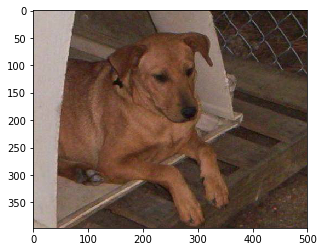

```python
plt.imshow(image)
```

The dataset includes 20000 training images and 5000 test images, each image at a different resolution. Loading all this data at once requires too much memory, so we will need to **resize** each image to a smaller, common size as we load them from disk. We can do so by again making use of a *scikit-image* function. For example:

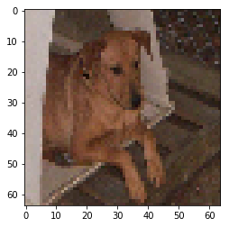

```python
from skimage.transform import resize

size = 64
smallimage = resize(image, (64, 64, 3), mode="reflect")  # 64 x 64 pixels, 3 color channels
plt.imshow(smallimage)
```

Perform the following tasks to prepare the data:

- Build a numpy array *X_train* containing one entry for each training image in the data. Each entry must contain the 3-dimensional matrix of pixels corresponding to an image. Make sure to scale down each image to a common size
- Normalize *X_train* so that pixels follow a distribution lying in the range [-0.5,0.5]
- Build a corresponding array *Y_train* with the class of each training image (0 for cats and 1 for dogs).
- Randomly shuffle the data. Make sure you shuffle both *X_train* and *Y_train* using the same permutation, so you don't lose track of the class of each training pattern.
- Repeat the whole procedure again to generate *X_test* and *Y_test* matrices for the test data. </font>
- Take advantage of the *glob* package to generate the filename lists for the indoor and outdoor subfolders.
- Since you need to repeat the procedure both for training and test data, it would be useful to implement a function that performs all the data loading and transforming steps. </font>

El código de abajo sólamente se ha utilizado para cargar los datos y generar los archivos binarios que utilizaremos para obtener las matrices X e y (de train y test). Es costoso, tarda un buen rato y es innecesario si se tienen los archivos binarios (vienen incluidos junto a este notebook); por lo tanto recomiendo al lector que no ejecute ninguna de las celdas que vienen a continuación y comience directamente desde la siguiente sección, en la que se cargan directamente los datos y nos ponemos a trabajar con ellos.

```python
####### INSERT YOUR CODE HERE
def get_matrices(direction='train', s=64, c=3, direc = 'drive/My Drive/images/'):
  '''
  Docstring
  ----------------------------------
  Parameters:
    - direction: 'train' or 'test'
    - s: size (rows, cols of img)
    - c: channels
    - direc: directory

  Returns:
    - X: images matrix
    - y: labels matrix
  '''
  import keras
  import random
  import numpy as np
  dogs = [resize(cv2.imread(file), (s, s, c), mode="reflect") for file in glob.glob(direc+direction+'/dogs/*.jpg')]
  print('tengo a los perros')
  cats = [resize(cv2.imread(file), (s, s, c), mode="reflect") for file in glob.glob(direc+direction+'/cats/*.jpg')]
  print('tengo a los gatos')
  # Merge cats and dogs
  X = cats + dogs
  #X = np.array(X, dtype=np.float32) - 0.5 #substract 0.5 to get the scale [-0.5, 0.5]

  y = [1]*len(cats) + [0]*len(dogs) #assign 1 to cats, 0 to dogs.
  #Y = keras.utils.np_utils.to_categorical(y, 2) #bidimensional hotencoder for the labels (helps keras).

  # With zip() we ensure that when we perform random shuffling all labels are kept track of, so that
  todo = list(zip(X, y))
  #random.seed(69)
  random.shuffle(todo)
  X[:], y[:] = zip(*todo)
  X = np.array(X, dtype=np.float32) - 0.5
  print('Finalizando parte de {}'.format(direction))
  return X,y
```

```python
X_train, y_train = get_matrices('train')
X_test, y_test = get_matrices('test')
```

[output not shown]

If everything has been properly loaded both X_train and Y_train lists should have equal length, and the same should happen for the pair X_test and Y_test.

```python
print("X_train size", len(X_train))
print("y_train size", len(y_train))
print("X_test size", len(X_test))
print("y_test size", len(y_test))
```

```python
def retrieve_name(var):
        """
        Gets the name of var. Does it from the out most frame inner-wards.
        :param var: variable to get name from.
        :return: string
        """
        for fi in reversed(inspect.stack()):
            names = [var_name for var_name, var_val in fi.frame.f_locals.items() if var_val is var]
            if len(names) > 0:
                return names[0]
```

```python
def create_binary_files(matrices=[X_train, X_test, y_train, y_test], direc = 'drive/My Drive/'):
  import gzip
  import pickle
  for matrix in matrices:

    nombre = retrieve_name(matrix)

    f = gzip.open(direc + nombre+'.pkz', 'wb', compresslevel=9)
    pickle.dump(matrix, f, protocol=3)
    print('archivo {} guardado en binario!!'.format(nombre))
    f.close()
```

```python
create_binary_files()
```

# INICIO DE LA PRÁCTICA

Si el usuario va a utilizar los archivos desde pickle directamente, puede comenzar desde esta parte del código. Todo lo anterior ha sido para leer correctamente las imágenes e introducirlas en archivos binarios. La idea es que esto, que inicialmente lleva bastante tiempo, pueda hacerse de forma más ágil a partir de la segunda vez que trabajemos con este código. Diseñaremos ahora una función para cargar desde binario las 4 matrices que necesitamos.

```python
!pip install scikit-optimize
!pip install lime
!pip install keras-explain
```

```
    100% |████████████████████████████████| 348kB 10.9MB/s
  Found existing installation: Keras 2.2.4
    Uninstalling Keras-2.2.4:
      Successfully uninstalled Keras-2.2.4
```

```python
import matplotlib.pyplot as plt
%matplotlib inline
import numpy as np
import pickle
import gzip
from google.colab import drive
drive.mount('/content/drive')
from keras.models import Sequential
from keras.layers.core import Dense
from keras.layers.core import Activation
from keras.layers.core import Dropout
from keras.layers.core import Flatten
from keras.layers.convolutional import Convolution2D, MaxPooling2D
from keras.wrappers.scikit_learn import KerasClassifier
from sklearn.model_selection import GridSearchCV, train_test_split
from keras.callbacks import EarlyStopping, ReduceLROnPlateau
import keras
from skopt import BayesSearchCV
from keras.preprocessing.image import ImageDataGenerator
from skopt.space import Real, Categorical, Integer

import matplotlib as mpl
from matplotlib.colors import ListedColormap
from sklearn.metrics import confusion_matrix, classification_report
import seaborn as sns
from numpy.random import seed
import pandas as pd
import os
from keras.layers import BatchNormalization
#from lime import lime_image
#import lime
from keras_explain.lime_ribeiro import Lime
from keras_explain.grad_cam import GuidedGradCam
from keras_explain.guided_bp import GuidedBP
from keras_explain.prediction_diff import PredictionDiff
```

Vamos a crear un dataframe para las imágenes de train y de validación, para poder más adelante utilizar el ImageDataGenerator. Los dejamos preparados.

```python
filenames = os.listdir("drive/My Drive/images/train/dogs") + os.listdir("drive/My Drive/images/train/cats")
```

```python
filenames2 = ['drive/My Drive/images/train/dogs/'+fname if "dog" in fname else 'drive/My Drive/images/train/cats/'+fname for fname in filenames]
```

```python
'''
filenames2=[]

for fname in filenames:
  if "dog" in fname:
    filenames2.append('drive/My Drive/images/train/dogs/'+fname)
  else:
    filenames2.append('drive/My Drive/images/train/cats/'+fname)
'''
```

```
'\nfilenames2=[]\n\nfor fname in filenames:\n  if "dog" in fname:\n    filenames2.append(\'drive/My Drive/images/train/dogs/\'+fname)\n  else:\n    filenames2.append(\'drive/My Drive/images/train/cats/\'+fname)\n'
```

```python
categories = []
for filename in filenames:
    category = filename.split('.')[0]
    if category == 'dog':
        categories.append(0)
    else:
        categories.append(1)

df = pd.DataFrame({
    'filename': filenames2,
    'category': categories
})

df['category'] = df['category'].astype('str');
```

```python
train_df, validate_df = train_test_split(df, test_size=0.20, random_state=42)
train_df = train_df.reset_index(drop=True)
validate_df = validate_df.reset_index(drop=True)
```

```python
#ponemos la semilla aleatoria.
seed(69)
```

```python
def get_binary(names=['X_train', 'X_test', 'y_train', 'y_test'], direc = 'drive/My Drive/'):

  data = {}

  for name in names:

    f = gzip.open(direc+'{}.pkz'.format(name), 'rb')
    data[name] = pickle.load(f)
    f.close()

  return data
```

```python
datos = get_binary()
```

```python
datos['X_test'].min()
```

```
-0.5
```

```python
X_train, X_test, y_train, y_test = datos['X_train'], datos['X_test'], datos['y_train'], datos['y_test']

trainvectors = X_train.reshape(20006, 64, 64, 3)
testvectors = X_test.reshape(5000, 64, 64, 3)
```

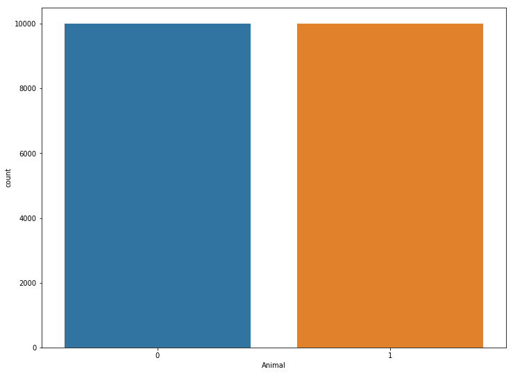

```python
ydf = pd.DataFrame(y_train, columns=['Animal'])

plt.rcParams['figure.figsize'] = (12, 9)
sns.countplot(x='Animal', data=ydf)
```

Vemos que ambas clases están balanceadas, por lo que utilizar el accuracy tendrá sentido.

## Basic deep model

Create a deep network that achieves at least a 60% of accuracy in the test set. Make use of the layers you seem fit for problem. You cannot use the test data for fitting the network, but you can use it to check the final performance of different network architectures, and select the architecture performing best.

If you are unable to attain the required 60% of accuracy, or your accuracy is too close to 100%, review the following checklist:

- Have you mixed training and test data?
- Have the values of the pixels been normalized?
- Have you compiled the model with a loss function appropriate for **binary** classification?
- Have you used ReLU units in the hidden layers? Have you used sigmoid or softmax layers in the output layer?

Vamos a utilizar dos callbacks en nuestros modelos. En primer lugar, utilizaremos el callback EarlyStopping que ya nos provee keras para poder dejar de entrenar cuando la pérdida esté dejando de bajar considerablemente, pues en ese momento estaremos empezando a modelizar el ruido más que la información contenida en las imágenes.

```python
class LossHistory(keras.callbacks.Callback):
    def on_train_begin(self, logs={}):
        self.losses = []
        self.accuracies = []

    def on_batch_end(self, batch, logs={}):
        self.losses.append(logs.get('loss'))
        self.accuracies.append(logs.get('accuracy'))
```

```python
####### INSERT YOUR CODE HERE

def basic_model(img_rows=64, img_cols=64, channels=3, kernel_size=3, pool_size=2, dropout=0.2):

  model = Sequential()
  model.add(Convolution2D(32, # Number convolution channels to generate
                        (kernel_size, kernel_size), # Size of convolution kernels
                        padding='valid', # Strategy to deal with borders
                        input_shape=(img_rows, img_cols, channels),
                         activation="relu"))
  model.add(Convolution2D(32, (kernel_size, kernel_size),
                         padding="valid"))
  model.add(MaxPooling2D(pool_size=(pool_size, pool_size)))
  model.add(Dropout(dropout))
  model.add(Flatten())
  model.add(Dense(128, activation="relu"))
  model.add(Dropout(dropout))
  model.add(Dense(1, activation="sigmoid"))
  model.compile(optimizer="adam", loss="binary_crossentropy", metrics=["accuracy"])
  return model
```

```python
model = basic_model()
lh=LossHistory()
history1=model.fit(trainvectors, y_train, batch_size=32, verbose=2, callbacks=[lh], validation_split=0.15, epochs=30)
```

```
WARNING:tensorflow:From /usr/local/lib/python3.6/dist-packages/tensorflow/python/framework/op_def_library.py:263: colocate_with (from tensorflow.python.framework.ops) is deprecated and will be removed in a future version.
Instructions for updating:
Colocations handled automatically by placer.
WARNING:tensorflow:From /usr/local/lib/python3.6/dist-packages/keras/backend/tensorflow_backend.py:3445: calling dropout (from tensorflow.python.ops.nn_ops) with keep_prob is deprecated and will be removed in a future version.
Instructions for updating:
Please use `rate` instead of `keep_prob`. Rate should be set to `rate = 1 - keep_prob`.
WARNING:tensorflow:From /usr/local/lib/python3.6/dist-packages/tensorflow/python/ops/math_ops.py:3066: to_int32 (from tensorflow.python.ops.math_ops) is deprecated and will be removed in a future version.
Instructions for updating:
Use tf.cast instead.
Train on 17005 samples, validate on 3001 samples
 - 12s - loss: 0.5894 - acc: 0.6837 - val_loss: 0.5311 - val_acc: 0.7314
 - 6s - loss: 0.4788 - acc: 0.7672 - val_loss: 0.5153 - val_acc: 0.7574
 - 6s - loss: 0.3582 - acc: 0.8415 - val_loss: 0.5051 - val_acc: 0.7544
 - 6s - loss: 0.2239 - acc: 0.9098 - val_loss: 0.6300 - val_acc: 0.7601
 - 6s - loss: 0.1151 - acc: 0.9580 - val_loss: 0.7250 - val_acc: 0.7637
 - 6s - loss: 0.0696 - acc: 0.9758 - val_loss: 0.7684 - val_acc: 0.7751
 - 6s - loss: 0.0510 - acc: 0.9828 - val_loss: 0.9993 - val_acc: 0.7647
 - 6s - loss: 0.0509 - acc: 0.9828 - val_loss: 0.9097 - val_acc: 0.7651
 - 6s - loss: 0.0457 - acc: 0.9850 - val_loss: 1.1124 - val_acc: 0.7664
 - 6s - loss: 0.0459 - acc: 0.9844 - val_loss: 0.9865 - val_acc: 0.7671
 - 6s - loss: 0.0366 - acc: 0.9879 - val_loss: 1.0582 - val_acc: 0.7601
 - 6s - loss: 0.0415 - acc: 0.9864 - val_loss: 1.3148 - val_acc: 0.7704
 - 6s - loss: 0.0317 - acc: 0.9892 - val_loss: 0.9654 - val_acc: 0.7617
 - 6s - loss: 0.0295 - acc: 0.9901 - val_loss: 1.1982 - val_acc: 0.7731
 - 6s - loss: 0.0312 - acc: 0.9894 - val_loss: 1.2523 - val_acc: 0.7671
 - 6s - loss: 0.0334 - acc: 0.9887 - val_loss: 1.2509 - val_acc: 0.7534
 - 6s - loss: 0.0215 - acc: 0.9926 - val_loss: 1.2674 - val_acc: 0.7461
 - 6s - loss: 0.0338 - acc: 0.9887 - val_loss: 1.5754 - val_acc: 0.7617
 - 6s - loss: 0.0358 - acc: 0.9892 - val_loss: 1.0532 - val_acc: 0.7501
 - 6s - loss: 0.0280 - acc: 0.9906 - val_loss: 1.3467 - val_acc: 0.7534
 - 6s - loss: 0.0267 - acc: 0.9912 - val_loss: 1.3523 - val_acc: 0.7521
 - 6s - loss: 0.0277 - acc: 0.9916 - val_loss: 1.4878 - val_acc: 0.7481
 - 6s - loss: 0.0313 - acc: 0.9900 - val_loss: 1.5383 - val_acc: 0.7564
 - 6s - loss: 0.0216 - acc: 0.9934 - val_loss: 1.6829 - val_acc: 0.7577
 - 6s - loss: 0.0177 - acc: 0.9940 - val_loss: 1.7593 - val_acc: 0.7527
 - 6s - loss: 0.0241 - acc: 0.9919 - val_loss: 1.8218 - val_acc: 0.7527
 - 6s - loss: 0.0245 - acc: 0.9927 - val_loss: 1.4380 - val_acc: 0.7611
 - 6s - loss: 0.0232 - acc: 0.9924 - val_loss: 1.7528 - val_acc: 0.7441
 - 6s - loss: 0.0245 - acc: 0.9923 - val_loss: 1.3461 - val_acc: 0.7664
 - 6s - loss: 0.0231 - acc: 0.9930 - val_loss: 1.6200 - val_acc: 0.7571
```

```python
acc1 = model.evaluate(testvectors, y_test)[1]

print('Accuracy obtenido en test por el modelo simple o básico: {}'.format(acc1))
```

```
Accuracy obtenido en test por el modelo simple o básico: 0.7592
```

```python
predictions1=model.predict_classes(testvectors)
```

```python
model.summary()
```

```
_________________________________________________________________
Layer (type)                 Output Shape              Param #
=================================================================
conv2d_1 (Conv2D)            (None, 62, 62, 32)        896
_________________________________________________________________
conv2d_2 (Conv2D)            (None, 60, 60, 32)        9248
_________________________________________________________________
max_pooling2d_1 (MaxPooling2 (None, 30, 30, 32)        0
_________________________________________________________________
dropout_1 (Dropout)          (None, 30, 30, 32)        0
_________________________________________________________________
flatten_1 (Flatten)          (None, 28800)             0
_________________________________________________________________
dense_1 (Dense)              (None, 128)               3686528
_________________________________________________________________
dropout_2 (Dropout)          (None, 128)               0
_________________________________________________________________
dense_2 (Dense)              (None, 1)                 129
=================================================================
Total params: 3,696,801
Trainable params: 3,696,801
Non-trainable params: 0
_________________________________________________________________
```

### Visualización del Accuracy y del Loss

```python
def plot_confusion_matrix(y_true, y_pred, classes,
                          normalize=True,
                          title=None,
                          cmap=plt.cm.Greens):
    """
    This function prints and plots the confusion matrix.
    Normalization can be applied by setting `normalize=True`.
    """
    if not title:
        if normalize:
            title = 'Normalized confusion matrix'
        else:
            title = 'Confusion matrix, without normalization'

    # Compute confusion matrix
    cm = confusion_matrix(y_true, y_pred)
    # Only use the labels that appear in the data
    #classes = classes[unique_labels(y_true, y_pred)]
    if normalize:
        cm = cm.astype('float') / cm.sum(axis=1)[:, np.newaxis]
        print("Normalized confusion matrix")
    else:
        print('Confusion matrix, without normalization')

    print(cm)

    fig, ax = plt.subplots()
    im = ax.imshow(cm, interpolation='nearest', cmap=cmap)
    ax.figure.colorbar(im, ax=ax)
    # We want to show all ticks...
    ax.set(xticks=np.arange(cm.shape[1]),
           yticks=np.arange(cm.shape[0]),
           # ... and label them with the respective list entries
           xticklabels=classes, yticklabels=classes,
           title=title,
           ylabel='True label',
           xlabel='Predicted label')

    # Rotate the tick labels and set their alignment.
    plt.setp(ax.get_xticklabels(), rotation=45, ha="right",
             rotation_mode="anchor")

    # Loop over data dimensions and create text annotations.
    fmt = '.2f' if normalize else 'd'
    thresh = cm.max() / 2.
    for i in range(cm.shape[0]):
        for j in range(cm.shape[1]):
            ax.text(j, i, format(cm[i, j], fmt),
                    ha="center", va="center",
                    color="white" if cm[i, j] > thresh else "black")
    fig.tight_layout()
    return ax
```

```
Normalized confusion matrix
[[0.6796 0.3204]
 [0.1612 0.8388]]
```

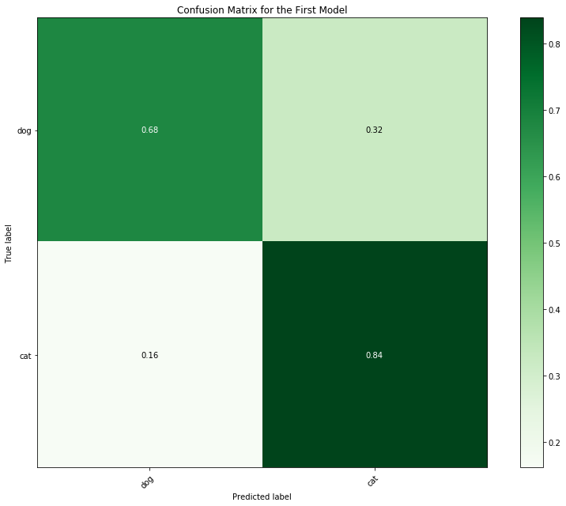

```python
plt.rcParams['figure.figsize'] = (12, 9)
plot_confusion_matrix(y_test, predictions1, classes=['dog', 'cat'], title='Confusion Matrix for the First Model')
```

Es algo que comprobaremos más adelante cuando veamos exactamente en qué imágenes se están equivocando los modelos, pero es probable que haya varias fotos de perros de esos muy mutados a los que han dado un aspecto casi ridículo y parecen gatos. Triste final para una especie proveniente de un ser tan feroz como el lobo. Sin embargo, nuestro ojo generalmente sí es capaz de identificar a estos seres como perros en lugar de gatos, por lo que debe de haber algunos elementos faciales o corporales que nos indican esta diferencia. Por lo tanto, los siguientes pasos irán destinados a mejorar este primer modelo, bastante pobre, para que podamos captar esas sutiles diferencias, y deje menos gatos y perros sin clasificar mal.

```python
def plot_performance(history, metric='acc', name='basic model'):

  plt.plot(history.history[metric])
  plt.plot(history.history['val_'+metric])
  plt.title('model {} {}'.format(name, metric))
  plt.ylabel(metric)
  plt.xlabel('epoch')
  plt.legend(['train', 'val'], loc='upper left')
  plt.show()



def plot_loss(history, name='basic model'):

  plt.plot(history.history['loss'])
  plt.plot(history.history['val_loss'])
  plt.title('{} loss'.format(name))
  plt.ylabel('loss')
  plt.xlabel('epoch')
  plt.legend(['train', 'val'], loc='upper left')
  plt.show()
```

```python
print(classification_report(y_test, predictions1))
```

```
              precision    recall  f1-score   support

           0       0.81      0.68      0.74      2500
           1       0.72      0.84      0.78      2500

   micro avg       0.76      0.76      0.76      5000
   macro avg       0.77      0.76      0.76      5000
weighted avg       0.77      0.76      0.76      5000
```

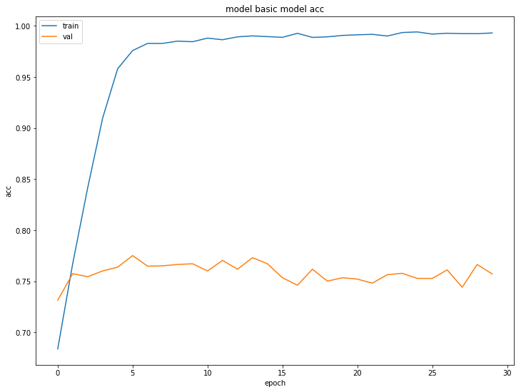

```python
plt.rcParams['figure.figsize'] = (12, 9)

plot_performance(history=history1)
```

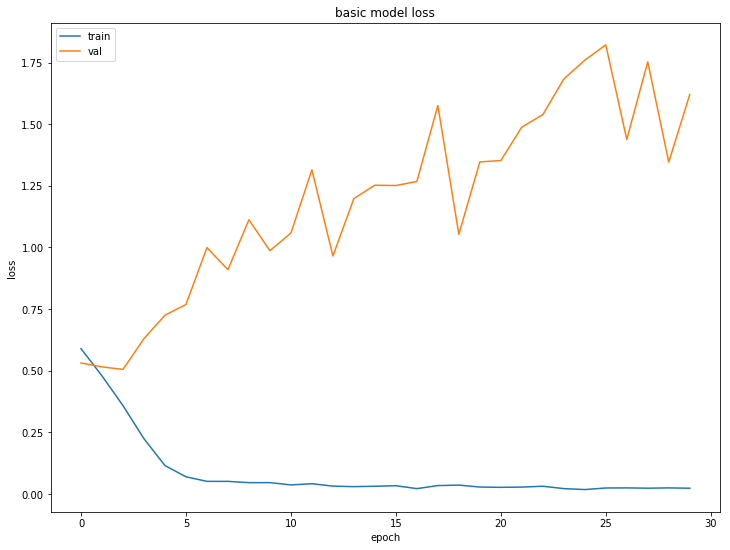

```python
plot_loss(history=history1)
```

Los gráficos de arriba nos muestran un perfecto ejemplo de overfitting, en el que mientras que vamos mejorando en el train tanto en términos de pérdida (binary crossentropy) como en términos de accuracy, en el conjunto de validación lo hacemos cada vez peor. Estos gráficos del entrenamiento de nuestras redes nos permiten visualizar qué está pasando en dicho entrenamiento, y así podemos ver si nuestro modelo realmente está aprendiendo a distinguir perros de gatos o simplemente se está conociendo las imágenes de entrenamiento "de memoria". En este primer modelo vemos que claramente no aprende cómo queremos. Esto se puede solucionar incluyendo más dropout en los hidden layers, para así favorecer la cooperación de las neuronas y no depender en exceso de ninguna de ellas para predecir las imágenes. Aunque esto limite cuánto pueden aprender los modelos, es precisamente esta limitación en el aprendizaje lo que nos prevee del sobreajuste.

*Nota Importante: Iremos escribiendo "del variable_name " de varios modelos, pues sino sobrecargaremos la RAM y será imposible seguir trabajando*

```python
del model
```

## A LITTLE BIT MORE ADVANCED MODEL

```python
def model2(n_conv=56, n_dense=496, img_rows=64, img_cols=64, channels=3, kernel_size=4, pool_size=2, dropout=0.3):

  model = Sequential()

  model.add(Convolution2D(n_conv, # Number convolution channels to generate
                        (kernel_size, kernel_size), # Size of convolution kernels
                        padding='valid', # Strategy to deal with borders
                        input_shape=(img_rows, img_cols, channels),
                         activation="relu"))

  model.add(BatchNormalization())

  model.add(MaxPooling2D(pool_size=(pool_size, pool_size), strides=2))
  model.add(Dropout(dropout/2))

  model.add(Convolution2D(n_conv,
                         (kernel_size, kernel_size),
                         padding='valid',
                         activation='relu'))

  model.add(BatchNormalization())
  model.add(MaxPooling2D(pool_size=(pool_size, pool_size), strides=2))
  model.add(Dropout(dropout/2))

  model.add(Convolution2D(n_conv,
                         (kernel_size, kernel_size),
                         padding='valid',
                         activation='relu'))
  model.add(BatchNormalization())
  model.add(MaxPooling2D(pool_size=(pool_size, pool_size),strides=2))
  model.add(Dropout(dropout/2))

  model.add(Convolution2D(n_conv*2, (kernel_size, kernel_size), padding='valid', activation='relu'))
  model.add(BatchNormalization())
  model.add(MaxPooling2D(pool_size=(pool_size, pool_size), strides=2))

  model.add(Flatten())
  model.add(Dropout(dropout/2))

  model.add(Dense(n_dense, activation='relu'))
  model.add(Dropout(dropout))

  model.add(BatchNormalization())

  model.add(Dense(n_dense, activation='relu'))
  model.add(Dropout(dropout))

  model.add(Dense(1, activation="sigmoid"))

  model.compile(loss='binary_crossentropy', optimizer='adam', metrics=['accuracy'])

  return model
```

```python
lh=LossHistory()
#es = EarlyStopping()
es = EarlyStopping(monitor='val_loss', patience = 10, min_delta=0.001, mode='min')

lr_red = ReduceLROnPlateau(monitor='val_acc',
                           patience=2,
                           verbose=1,
                           factor=0.5,
                           min_lr=0.00001)
```

```python
model2=model2(dropout=0.5)
history2=model2.fit(trainvectors, y_train, batch_size=128, verbose=2, callbacks=[lh, es, lr_red], validation_split=0.15, epochs=100)
```

```
Train on 17005 samples, validate on 3001 samples
 - 7s - loss: 0.7700 - acc: 0.5737 - val_loss: 0.6433 - val_acc: 0.6368
 - 6s - loss: 0.6626 - acc: 0.6358 - val_loss: 0.6528 - val_acc: 0.6435
 - 6s - loss: 0.5752 - acc: 0.7019 - val_loss: 0.6049 - val_acc: 0.6994
 - 6s - loss: 0.5164 - acc: 0.7418 - val_loss: 0.5217 - val_acc: 0.7378
 - 6s - loss: 0.4664 - acc: 0.7780 - val_loss: 0.4387 - val_acc: 0.8041
 - 6s - loss: 0.4333 - acc: 0.7977 - val_loss: 0.4511 - val_acc: 0.7924
 - 6s - loss: 0.4000 - acc: 0.8190 - val_loss: 0.4081 - val_acc: 0.8117
 - 6s - loss: 0.3743 - acc: 0.8346 - val_loss: 0.3841 - val_acc: 0.8297
 - 6s - loss: 0.3560 - acc: 0.8396 - val_loss: 0.4023 - val_acc: 0.8124
 - 6s - loss: 0.3370 - acc: 0.8503 - val_loss: 0.3832 - val_acc: 0.8167

Epoch 00010: ReduceLROnPlateau reducing learning rate to 0.0005000000237487257.
 - 6s - loss: 0.2929 - acc: 0.8726 - val_loss: 0.3203 - val_acc: 0.8657
 - 6s - loss: 0.2793 - acc: 0.8807 - val_loss: 0.5091 - val_acc: 0.7831
 - 6s - loss: 0.2752 - acc: 0.8829 - val_loss: 0.3059 - val_acc: 0.8664
 - 6s - loss: 0.2623 - acc: 0.8867 - val_loss: 0.3159 - val_acc: 0.8684
 - 6s - loss: 0.2488 - acc: 0.8940 - val_loss: 0.3140 - val_acc: 0.8714
 - 6s - loss: 0.2404 - acc: 0.8953 - val_loss: 0.3114 - val_acc: 0.8724
 - 6s - loss: 0.2274 - acc: 0.9023 - val_loss: 0.2867 - val_acc: 0.8800
 - 6s - loss: 0.2219 - acc: 0.9075 - val_loss: 0.3150 - val_acc: 0.8674
 - 6s - loss: 0.2191 - acc: 0.9083 - val_loss: 0.2787 - val_acc: 0.8884
 - 6s - loss: 0.2037 - acc: 0.9145 - val_loss: 0.2830 - val_acc: 0.8840
 - 6s - loss: 0.2004 - acc: 0.9156 - val_loss: 0.3113 - val_acc: 0.8824

Epoch 00021: ReduceLROnPlateau reducing learning rate to 0.0002500000118743628.
 - 6s - loss: 0.1767 - acc: 0.9297 - val_loss: 0.2927 - val_acc: 0.8920
 - 6s - loss: 0.1699 - acc: 0.9300 - val_loss: 0.2934 - val_acc: 0.8860
 - 6s - loss: 0.1602 - acc: 0.9332 - val_loss: 0.2884 - val_acc: 0.8914

Epoch 00024: ReduceLROnPlateau reducing learning rate to 0.0001250000059371814.
 - 6s - loss: 0.1502 - acc: 0.9388 - val_loss: 0.3002 - val_acc: 0.8890
 - 6s - loss: 0.1463 - acc: 0.9420 - val_loss: 0.2878 - val_acc: 0.9004
 - 6s - loss: 0.1386 - acc: 0.9444 - val_loss: 0.3017 - val_acc: 0.8907
 - 6s - loss: 0.1429 - acc: 0.9417 - val_loss: 0.3048 - val_acc: 0.8897

Epoch 00028: ReduceLROnPlateau reducing learning rate to 6.25000029685907e-05.
 - 6s - loss: 0.1351 - acc: 0.9437 - val_loss: 0.2970 - val_acc: 0.8970
```

```python
predictions2=model2.predict_classes(testvectors)

model2.evaluate(testvectors, y_test)
```

```
[0.29061772457361223, 0.8942]
```

```
Normalized confusion matrix
[[0.886  0.114 ]
 [0.0976 0.9024]]
```

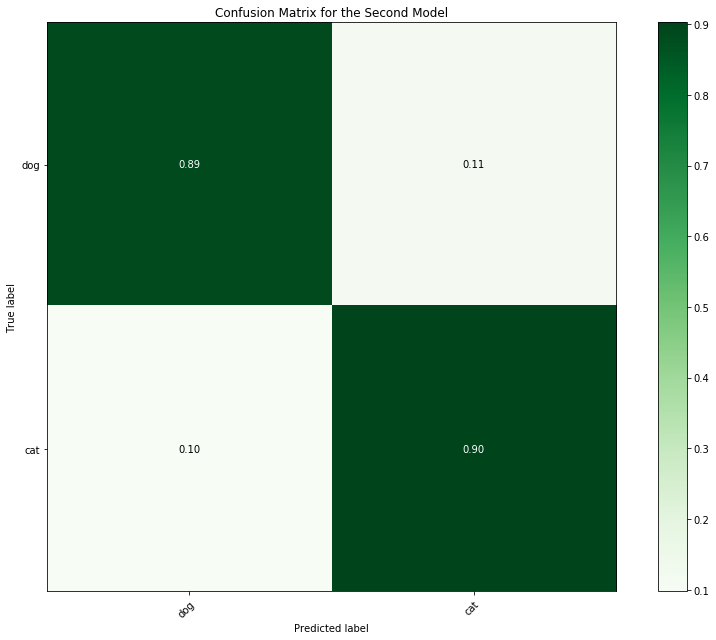

```python
plt.rcParams['figure.figsize'] = (12, 9)
plot_confusion_matrix(y_test, predictions2, classes=['dog', 'cat'], title='Confusion Matrix for the Second Model')
```

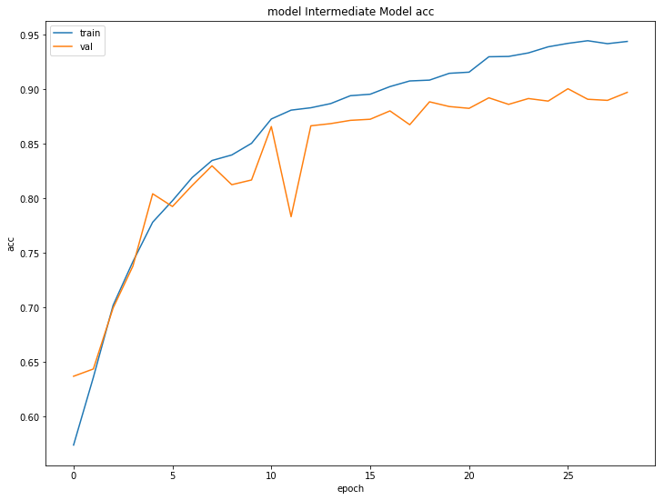

```python
plot_performance(history=history2, name='Intermediate Model')
```

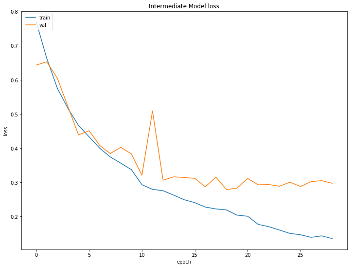

```python
plot_loss(history=history2, name='Intermediate Model')
```

## Improving the network

You can further improve your results by applying one or more of the following strategies:

- Keep apart a portion of the training data as a **validation set**. Then use an [**EarlyStopping strategy**](https://keras.io/callbacks/#earlystopping) to monitor the loss of these validation data, and stop when training when after a number of iterations such loss has not decreased.
- Make use of **metamodelling techniques** to select the best architecture parameters for the networks. You can use scikit-learn methods GridSearchCV or RandomSearchCV. You can do those by using the [KerasClassifier](https://keras.io/scikit-learn-api/) wrapper. Even better, you can mix KerasClassifier with an advanced search method such as [BayesSearch](https://scikit-optimize.github.io/#skopt.BayesSearchCV), included in the [scikit-optimize](https://scikit-optimize.github.io/) library.
- Use **image augmentation techniques** to artifically create new training images. To do so, you can make use of [ImageDataGenerator](https://keras.io/preprocessing/image/) in Keras.
- Make use of a pre-trained large network, building your network on top of it. You can find some examples in the [Keras Applications](https://keras.io/applications/) page.

If you correctly use these techniques you should be able to improve your model. With some effort it is possible to up to a 90% test accuracy. Try to do your best!</font>

## DEEP NETWORK HYPERPARAMETER TUNING

Vamos a utilizar el wrapper de scikit learn con keras para hacer búsqueda del mejor dropout rate para este problema. Podríamos hacer esto con prácticamente todos los parámetros que le introducimos a nuestra red. Lo único que tendríamos que hacer es meter el número de neuronas como parámetro de la función basic_model(), para introducir esto en lugar de los 32, 128 etc que vemos arriba (estos números representan el número de neuronas en cada capa de las que vemos arriba). Sin embargo, si no lo hacemos ahora mismo es porque el tiempo de entrenamiento requerido sería altísimo. El número de imágenes es grande para nuestro ordenador y cada modelo individual tarda mucho en entrenarse. En un problema del mundo real merecería la pena hacer el hyperparameter tuning completo, para así obtener el modelo que más dinero nos haga ahorrar o más dinero nos haga ganar (en la vida real un 1-2% más de accuracy puede suponer miles de euros).

```python
####### INSERT YOUR CODE HERE
model = KerasClassifier(build_fn=basic_model, epochs=25, batch_size=32, verbose=1)

param_grid = {'dropout':[0.3, 0.4]}

grid = GridSearchCV(estimator=model, param_grid=param_grid, n_jobs=-1, verbose=1, cv=3)

grid.fit(trainvectors, y_train)
```

```
Fitting 3 folds for each of 2 candidates, totalling 6 fits
```

```
[Parallel(n_jobs=-1)]: Using backend LokyBackend with 2 concurrent workers.
[Parallel(n_jobs=-1)]: Done   6 out of   6 | elapsed: 11.3min finished
```

```
GridSearchCV(cv=3, error_score='raise-deprecating',
       estimator=<keras.wrappers.scikit_learn.KerasClassifier object at 0x7ff25ae9f860>,
       fit_params=None, iid='warn', n_jobs=-1,
       param_grid={'dropout': [0.3, 0.4]}, pre_dispatch='2*n_jobs',
       refit=True, return_train_score='warn', scoring=None, verbose=1)
```

```python
model_tuned = basic_model(dropout=grid.best_params_['dropout'])

es = EarlyStopping(monitor='val_loss', mode='min', patience=20)
lh = LossHistory()
history3=model_tuned.fit(trainvectors, y_train, epochs=100, batch_size=32,
                verbose=2, validation_split=0.15, callbacks=[es, lh])
```

```
Train on 17005 samples, validate on 3001 samples
 - 7s - loss: 0.5935 - acc: 0.6763 - val_loss: 0.5230 - val_acc: 0.7321
 - 6s - loss: 0.4924 - acc: 0.7621 - val_loss: 0.5249 - val_acc: 0.7611
 - 6s - loss: 0.4079 - acc: 0.8131 - val_loss: 0.5122 - val_acc: 0.7604
 - 6s - loss: 0.3192 - acc: 0.8607 - val_loss: 0.5042 - val_acc: 0.7817
 - 6s - loss: 0.2344 - acc: 0.9043 - val_loss: 0.5682 - val_acc: 0.7714
 - 6s - loss: 0.1663 - acc: 0.9340 - val_loss: 0.6422 - val_acc: 0.7794
 - 6s - loss: 0.1251 - acc: 0.9522 - val_loss: 0.6895 - val_acc: 0.7871
 - 6s - loss: 0.1077 - acc: 0.9612 - val_loss: 0.7192 - val_acc: 0.7694
 - 6s - loss: 0.0914 - acc: 0.9671 - val_loss: 0.9063 - val_acc: 0.7724
 - 6s - loss: 0.0816 - acc: 0.9701 - val_loss: 0.8568 - val_acc: 0.7767
 - 6s - loss: 0.0819 - acc: 0.9711 - val_loss: 0.8272 - val_acc: 0.7711
 - 6s - loss: 0.0804 - acc: 0.9700 - val_loss: 0.9337 - val_acc: 0.7691
 - 6s - loss: 0.0656 - acc: 0.9780 - val_loss: 0.8619 - val_acc: 0.7634
 - 6s - loss: 0.0648 - acc: 0.9771 - val_loss: 0.8940 - val_acc: 0.7634
 - 6s - loss: 0.0637 - acc: 0.9779 - val_loss: 0.9435 - val_acc: 0.7601
 - 6s - loss: 0.0549 - acc: 0.9812 - val_loss: 1.1262 - val_acc: 0.7694
 - 6s - loss: 0.0616 - acc: 0.9791 - val_loss: 0.9212 - val_acc: 0.7731
 - 6s - loss: 0.0583 - acc: 0.9799 - val_loss: 0.8643 - val_acc: 0.7671
 - 6s - loss: 0.0565 - acc: 0.9814 - val_loss: 0.8923 - val_acc: 0.7714
 - 6s - loss: 0.0545 - acc: 0.9814 - val_loss: 0.9926 - val_acc: 0.7851
 - 6s - loss: 0.0589 - acc: 0.9802 - val_loss: 1.0541 - val_acc: 0.7767
 - 6s - loss: 0.0476 - acc: 0.9841 - val_loss: 1.2020 - val_acc: 0.7821
 - 6s - loss: 0.0551 - acc: 0.9815 - val_loss: 0.9332 - val_acc: 0.7634
 - 6s - loss: 0.0498 - acc: 0.9833 - val_loss: 0.9925 - val_acc: 0.7694
```

```python
acc3=model_tuned.evaluate(testvectors, y_test)[1]

print('Ajustando un poco el dropout tenemos un accuracy de {}'.format(acc3))
```

```
Ajustando un poco el dropout tenemos un accuracy de 0.7718
```

```python
predictions3 = model_tuned.predict_classes(testvectors)
```

```
Normalized confusion matrix
[[0.7276 0.2724]
 [0.184  0.816 ]]
```

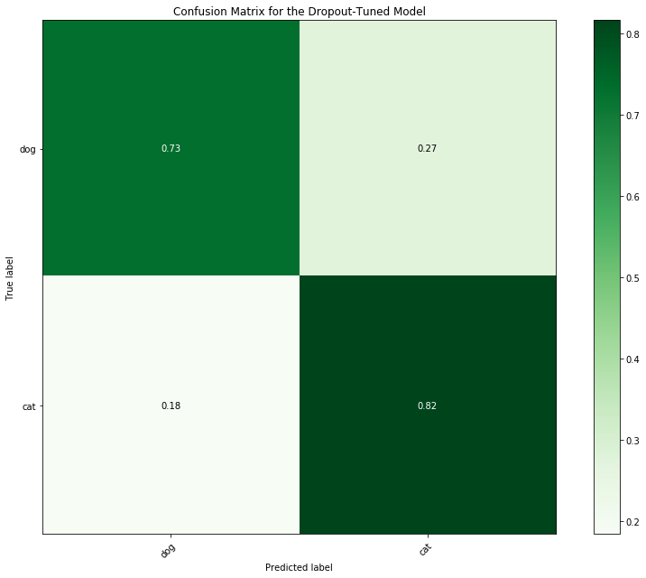

```python
plot_confusion_matrix(y_test, predictions3, classes=['dog', 'cat'], title='Confusion Matrix for the Dropout-Tuned Model')
```

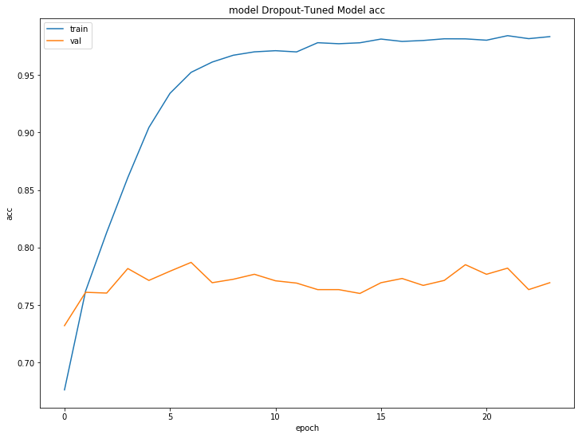

```python
plot_performance(history=history3, name='Dropout-Tuned Model')
```

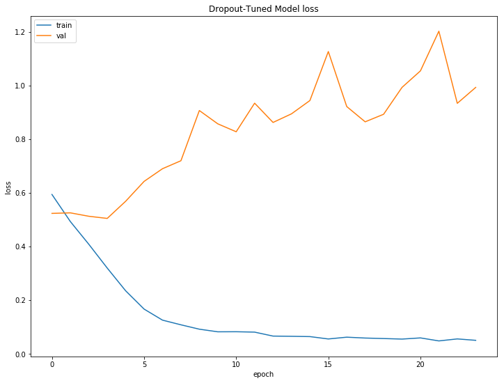

```python
plot_loss(history=history3, name='Dropout-Tuned Model')
```

Pese a introducirle un dropout más alto, el modelo sigue haciendo overfittig.

### BayesSearchCV

Sin embargo, haciendo uso del BayesSearchCV podemos diseñar un espacio muestral de parámetros grande y determinar el número de subespacios se probarán para quedarse con el que mejor resultado nos de. Por esto, puede tener sentido hacer un hyperparameter tuning más completo que el que hicimos antes únicamente sobre el dropout.

```python
def model2(n_conv=32, n_dense=400, img_rows=64, img_cols=64, channels=3, kernel_size=3, pool_size=2, dropout=0.4):

  model = Sequential()

  model.add(Convolution2D(n_conv, # Number convolution channels to generate
                        (kernel_size, kernel_size), # Size of convolution kernels
                        padding='valid', # Strategy to deal with borders
                        input_shape=(img_rows, img_cols, channels),
                         activation="relu"))

  model.add(MaxPooling2D(pool_size=(pool_size, pool_size), strides=2))
  model.add(Dropout(dropout/2))

  model.add(Convolution2D(n_conv,
                         (kernel_size, kernel_size),
                         padding='valid',
                         activation='relu'))
  model.add(MaxPooling2D(pool_size=(pool_size, pool_size), strides=2))
  model.add(Dropout(dropout/2))

  model.add(Convolution2D(n_conv,
                         (kernel_size, kernel_size),
                         padding='valid',
                         activation='relu'))
  model.add(MaxPooling2D(pool_size=(pool_size, pool_size),strides=2))
  model.add(Dropout(dropout/2))
  model.add(Convolution2D(n_conv, (kernel_size, kernel_size), padding='valid', activation='relu'))
  model.add(MaxPooling2D(pool_size=(pool_size, pool_size), strides=2))
  model.add(Flatten())
  model.add(Dropout(dropout/2))
  model.add(Dense(n_dense, activation="relu"))
  model.add(Dropout(dropout))

  model.add(Dense(1, activation="sigmoid"))

  model.compile(loss='binary_crossentropy', optimizer='adam', metrics=['accuracy'])

  return model
```

```python
model2 = KerasClassifier(build_fn=model2, epochs=20, batch_size=128, verbose=2)

param_grid = {'n_conv':Integer(16,64),
             'n_dense':Integer(64, 512),
             'dropout':Real(0.2, 0.5, prior='log-uniform')}

search = BayesSearchCV(estimator=model2, search_spaces=param_grid, n_iter=4, n_jobs=2, cv=3, random_state=69, scoring='accuracy')
search.fit(trainvectors, datos['y_train'])
```

```
 - 5s - loss: 0.6524 - acc: 0.6016
 - 4s - loss: 0.5505 - acc: 0.7175
 - 4s - loss: 0.4743 - acc: 0.7748
 - 4s - loss: 0.4177 - acc: 0.8067
 - 4s - loss: 0.3829 - acc: 0.8301
 - 4s - loss: 0.3496 - acc: 0.8461
 - 4s - loss: 0.3201 - acc: 0.8621
 - 4s - loss: 0.3024 - acc: 0.8680
 - 4s - loss: 0.2760 - acc: 0.8814
 - 4s - loss: 0.2624 - acc: 0.8898
 - 4s - loss: 0.2445 - acc: 0.8976
 - 4s - loss: 0.2342 - acc: 0.8999
 - 4s - loss: 0.2202 - acc: 0.9090
 - 4s - loss: 0.2150 - acc: 0.9115
 - 4s - loss: 0.2036 - acc: 0.9154
 - 4s - loss: 0.1950 - acc: 0.9200
 - 4s - loss: 0.1832 - acc: 0.9240
 - 4s - loss: 0.1718 - acc: 0.9301
 - 4s - loss: 0.1708 - acc: 0.9279
 - 4s - loss: 0.1617 - acc: 0.9336
```

```
BayesSearchCV(cv=3, error_score='raise',
       estimator=<keras.wrappers.scikit_learn.KerasClassifier object at 0x7ff25aea5470>,
       fit_params=None, iid=True, n_iter=4, n_jobs=2, n_points=1,
       optimizer_kwargs=None, pre_dispatch='2*n_jobs', random_state=69,
       refit=True, return_train_score=False, scoring='accuracy',
       search_spaces={'n_conv': Integer(low=16, high=64), 'n_dense': Integer(low=64, high=512), 'dropout': Real(low=0.2, high=0.5, prior='log-uniform', transform='identity')},
       verbose=0)
```

```python
try:
  f = gzip.open('drive/My Drive/modelbayesiansearch.pkz', 'wb', compresslevel=9)
  pickle.dump(history3, f, protocol=3)
except:
  f = gzip.open('drive/My Drive/modelbayesiansearch.pkz', 'wb', compresslevel=9)
  pickle.dump(search, f, protocol=3)
```

```python
search.score(testvectors, y_test)
```

```
0.8908
```

```python
predictions4=search.best_estimator_.predict(testvectors)
```

```python
print(search.cv_results_)
```

[output not shown]

```python
search.best_params_
```

```
{'dropout': 0.27314962103377294, 'n_conv': 56, 'n_dense': 496}
```

```python
search.best_estimator_
```

```
<keras.wrappers.scikit_learn.KerasClassifier at 0x7ff25af265f8>
```

```
Normalized confusion matrix
[[0.886  0.114 ]
 [0.1044 0.8956]]
```

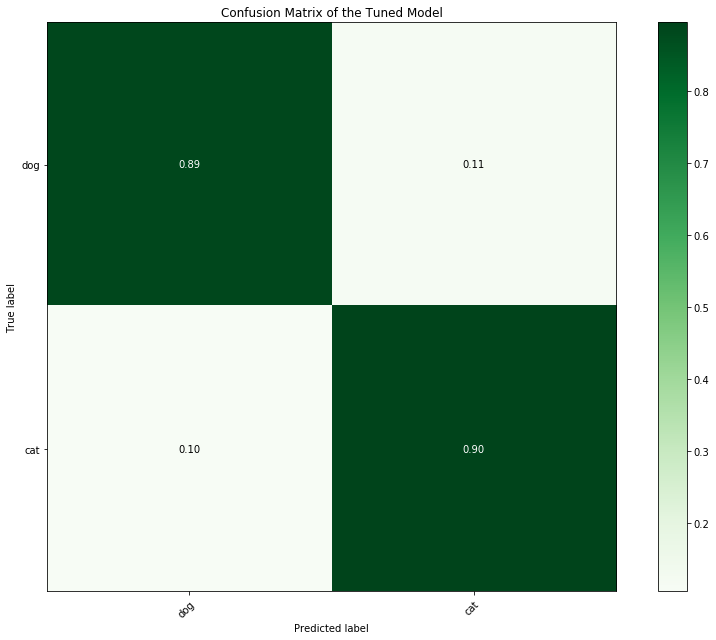

```python
plot_confusion_matrix(y_test, predictions4, classes=['dog', 'cat'], title='Confusion Matrix of the Tuned Model')
```

## TRYING LENET ARQUITECTURE WITH HYPERPARAMETER TUNING

Como en el resto de partes de este notebook en las que hacemos hyperparameter tuning, lo hacemos "de mentira", es decir dejando muy pocas iteraciones a los modelos de optimización para seleccionar los mejores hiperparámetros y dejando también a los modelos entrenar durante pocas épocas. El objetivo es más mostrar cómo se haría que obtener resultados óptimos, pues nuestras limitaciones de hardware nos impiden entrenar estos modelos en un tiempo razonable (pese a usar las GPUs de Google, el problema a veces es de memoria más que de GPU; en este segundo caso directamente ni con todo el tiempo del mundo podríamos hacerlo, pues los resultados intermedios que necesita BayesSearchCV o cualquier otro "metamodelling technique" ocupan demasiado en memoria para poder ser guardados ).

```python
def LeNet(n_conv1 = 20, n_conv2 = 50,n_dense=500, kernel_size=5, channels=3,img_rows = 64, img_cols = 64, pool_size = 2, dropout=0.25):
  model=Sequential()
  model.add(Convolution2D(n_conv1,(kernel_size, kernel_size), padding="valid", input_shape=(img_rows, img_cols, channels), activation="relu"))
  model.add(MaxPooling2D(pool_size = (pool_size, pool_size), strides=2))
  model.add(Dropout(dropout))
  model.add(Convolution2D(n_conv2, (kernel_size, kernel_size), activation= "relu", padding="valid"))
  model.add(MaxPooling2D(pool_size = (pool_size, pool_size), strides=2))
  model.add(Dropout(dropout))
  model.add(Flatten())
  model.add(Dense(n_dense, activation="relu"))
  model.add(Dropout(dropout*2))
  model.add(Dense(1, activation="sigmoid"))
  model.compile(optimizer="adam", loss="binary_crossentropy", metrics = ["accuracy"])
  return model
```

```python
modelLeNet = KerasClassifier(build_fn=LeNet, epochs=20, batch_size=128, verbose=1)

param_grid_LN = {'n_conv1':Integer(16,64),
              'n_conv2':Integer(16, 64),
             'n_dense':Integer(64, 512),
             'dropout':Real(0.2, 0.5, prior='log-uniform')}

searchLeNet = BayesSearchCV(estimator=modelLeNet, search_spaces=param_grid_LN, n_iter=3, n_jobs=-1, cv=3, random_state=69, scoring='accuracy')
searchLeNet.fit(trainvectors, y_train)
```

```
BayesSearchCV(cv=3, error_score='raise',
       estimator=<keras.wrappers.scikit_learn.KerasClassifier object at 0x7ff228c52e80>,
       fit_params=None, iid=True, n_iter=3, n_jobs=-1, n_points=1,
       optimizer_kwargs=None, pre_dispatch='2*n_jobs', random_state=69,
       refit=True, return_train_score=False, scoring='accuracy',
       search_spaces={'n_conv1': Integer(low=16, high=64), 'n_conv2': Integer(low=16, high=64), 'n_dense': Integer(low=64, high=512), 'dropout': Real(low=0.2, high=0.5, prior='log-uniform', transform='identity')},
       verbose=0)
```

```python
predsLeNet = searchLeNet.best_estimator_.predict(testvectors)

print(classification_report(y_test, predsLeNet))
```

```
              precision    recall  f1-score   support

           0       0.85      0.85      0.85      2500
           1       0.85      0.85      0.85      2500

   micro avg       0.85      0.85      0.85      5000
   macro avg       0.85      0.85      0.85      5000
weighted avg       0.85      0.85      0.85      5000
```

```python
#searchLeNet.best_estimator_.evaluate(testvectors, y_test)
```

```
Normalized confusion matrix
[[0.854  0.146 ]
 [0.1548 0.8452]]
```

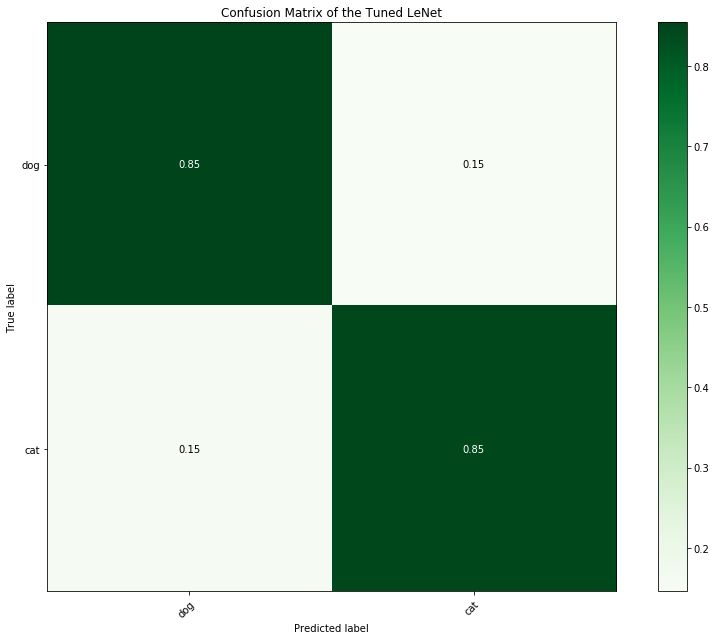

```python
plot_confusion_matrix(y_test, predsLeNet, classes=['dog', 'cat'], title='Confusion Matrix of the Tuned LeNet')
```

Como vemos, LeNet no mejora al modelo intermedio que presentamos antes, pero se queda cerca, con un accuracy de 0.85

```python
del searchLeNet
```

```python
del model_tuned
del grid
```

## DATA AUGMENTATION TECHNIQUES

```python
def model2(n_conv=32, n_dense=400, img_rows=64, img_cols=64, channels=3, kernel_size=3, pool_size=2, dropout=0.4):

  model = Sequential()

  model.add(Convolution2D(n_conv, # Number convolution channels to generate
                        (kernel_size, kernel_size), # Size of convolution kernels
                        padding='valid', # Strategy to deal with borders
                        input_shape=(img_rows, img_cols, channels),
                         activation="relu"))

  model.add(MaxPooling2D(pool_size=(pool_size, pool_size), strides=2))
  model.add(Dropout(dropout/2))

  model.add(Convolution2D(n_conv,
                         (kernel_size, kernel_size),
                         padding='valid',
                         activation='relu'))
  model.add(MaxPooling2D(pool_size=(pool_size, pool_size), strides=2))
  model.add(Dropout(dropout/2))

  model.add(Convolution2D(n_conv,
                         (kernel_size, kernel_size),
                         padding='valid',
                         activation='relu'))
  model.add(MaxPooling2D(pool_size=(pool_size, pool_size),strides=2))
  model.add(Dropout(dropout/2))
  model.add(Convolution2D(n_conv, (kernel_size, kernel_size), padding='valid', activation='relu'))
  model.add(MaxPooling2D(pool_size=(pool_size, pool_size), strides=2))
  model.add(Flatten())
  model.add(Dropout(dropout/2))
  model.add(Dense(n_dense, activation="relu"))
  model.add(Dropout(dropout))

  model.add(Dense(1, activation="sigmoid"))

  model.compile(loss='binary_crossentropy', optimizer='adam', metrics=['accuracy'])

  return model


generator = ImageDataGenerator(zoom_range=0.25, rotation_range=15.,
		 channel_shift_range=25., width_shift_range=0.02, height_shift_range=0.02,
		 horizontal_flip=True, fill_mode='constant')
```

```python
#train, xval, ytrain, yval = train_test_split(trainvectors, y_train, test_size = 0.2, random_state=69)
```

```python
es = EarlyStopping(monitor='loss', mode='min', patience=10, min_delta=0.01)
lh = LossHistory()




generator.fit(trainvectors)

modelAugmented = model2()


# fits the model on batches with real-time data augmentation:
historyAugmented=modelAugmented.fit_generator(generator.flow(trainvectors, y_train, batch_size=128),
                    steps_per_epoch=len(trainvectors) / 128, epochs=50, callbacks=[lh, es])
```

```python
predictions5 = modelAugmented.predict_classes(testvectors)

print(classification_report(y_test, predictions5))
```

```
              precision    recall  f1-score   support

           0       0.50      1.00      0.67      2500
           1       0.00      0.00      0.00      2500

   micro avg       0.50      0.50      0.50      5000
   macro avg       0.25      0.50      0.33      5000
weighted avg       0.25      0.50      0.33      5000
```

```
Normalized confusion matrix
[[1. 0.]
 [1. 0.]]
```

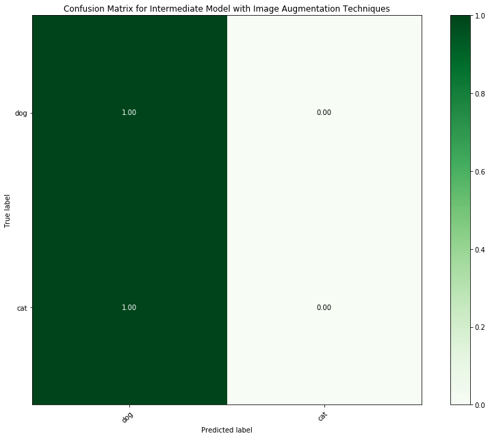

```python
plot_confusion_matrix(y_test, predictions5, classes=['dog', 'cat'], title='Confusion Matrix for Intermediate Model with Image Augmentation Techniques')
```

```python
#plot_performance(history=historyAugmented, name='ImageAugmentation Model')
```

```python
#plot_loss(history=historyAugmented, name='ImageAugmentation Model')
```

### DATA AUGMENTATION WITH FLOW FROM DATAFRAME

```python
def preproc(x):
  return x-0.5

train_datagen = ImageDataGenerator(
    rotation_range=15,
    rescale=1./255,
    shear_range=0.1,
    zoom_range=0.2,
    horizontal_flip=True,
    width_shift_range=0.1,
    height_shift_range=0.1
)
''',
    preprocessing_function=preproc
)
'''
train_generator = train_datagen.flow_from_dataframe(
    train_df,
    None,
    x_col='filename',
    y_col='category',
    target_size=(64,64),
    class_mode='binary',
    batch_size=32
)
```

```
Found 16004 images belonging to 2 classes.
```

```python
validation_datagen = ImageDataGenerator(rescale=1./255)
validation_generator = validation_datagen.flow_from_dataframe(
    validate_df,
    None,
    x_col='filename',
    y_col='category',
    target_size=(64,64),
    class_mode='binary',
    batch_size=32
)
```

```
Found 4002 images belonging to 2 classes.
```

En el código inferior vemos que el transformador de imágenes funciona correctamente, pues genera a partir de una imagen de un gato y un perro diferentes imágenes, girando la foto, cambiándole el ángulo, acercándola etc.

```python
train_df.head()
```

|  | filename | category |
| --- | --- | --- |
| 0 | drive/My Drive/images/train/cats/cat.7115.jpg | 1 |
| 1 | drive/My Drive/images/train/dogs/dog.876.jpg | 0 |
| 2 | drive/My Drive/images/train/dogs/dog.7803.jpg | 0 |
| 3 | drive/My Drive/images/train/dogs/dog.3708.jpg | 0 |
| 4 | drive/My Drive/images/train/cats/cat.5842.jpg | 1 |

```python
#example_df = train_df.sample(n=2).reset_index(drop=True)

example_df = train_df.iloc[:2, :].reset_index(drop=True)
example_generator = train_datagen.flow_from_dataframe(
    example_df,
    None,
    x_col='filename',
    y_col='category',
    target_size=(64,64),
    class_mode='binary'
)
```

```
Found 2 images belonging to 2 classes.
```

```python
for X_batch, Y_batch in example_generator:
  print(X_batch)
```

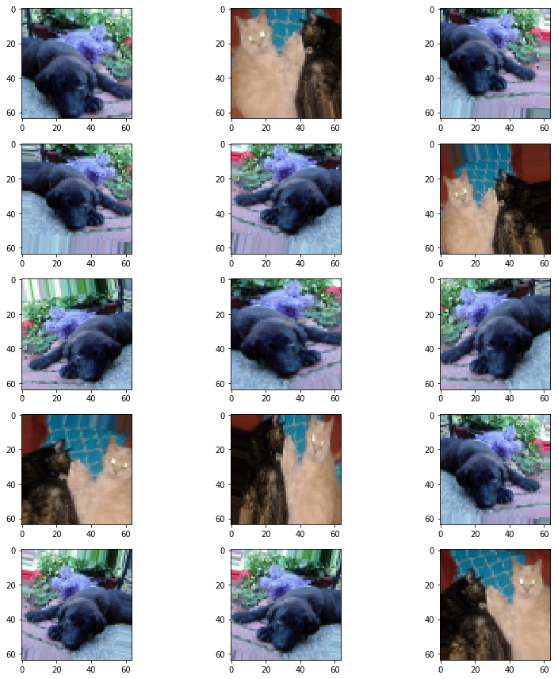

```python
plt.figure(figsize=(12, 12))
for i in range(0, 15):
    plt.subplot(5, 3, i+1)
    for X_batch, Y_batch in example_generator:
        image = X_batch[0]
        plt.imshow(image)
        break
plt.tight_layout()
plt.show()
```

```python
modelAug = model2()

history = modelAug.fit_generator(
    train_generator,
    steps_per_epoch=100,
    epochs=100,
    validation_data=validation_generator,
    validation_steps=50, callbacks=[lh, es])
```

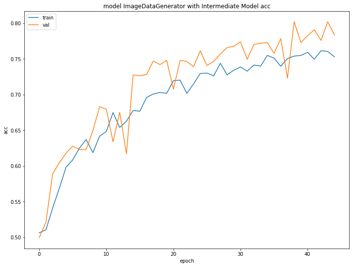

```python
plot_performance(history=history, name='ImageDataGenerator with Intermediate Model')
```

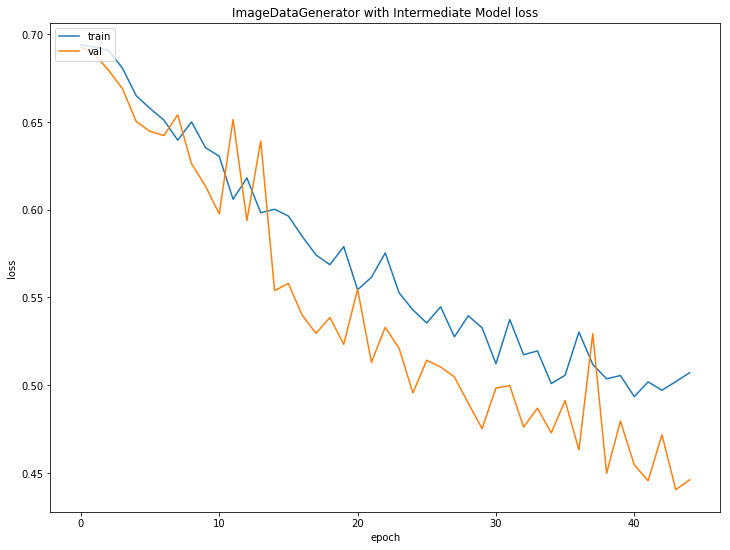

```python
plot_loss(history=history, name='ImageDataGenerator with Intermediate Model')
```

```python
test_filenames = os.listdir("drive/My Drive/images/test/dogs") + os.listdir("drive/My Drive/images/test/cats")

categories = []
for filename in test_filenames:
    category = filename.split('.')[0]
    if category == 'dog':
        categories.append(0)
    else:
        categories.append(1)


test_filenames2 = ['drive/My Drive/images/test/dogs/'+fname if "dog" in fname else 'drive/My Drive/images/test/cats/'+fname for fname in test_filenames]

test_df = pd.DataFrame({
    'filename': test_filenames2,
    'category': categories
})

test_df['category'] = test_df['category'].astype('str')
```

```python
#test_df.head()
```

```python
test_gen = ImageDataGenerator(rescale=1./255)
test_generator = test_gen.flow_from_dataframe(
    test_df,
    None,
    x_col='filename',
    y_col='category',
    class_mode='binary',
    target_size=(64,64),
    batch_size=10,
    shuffle=False
)
```

```
Found 5000 images belonging to 2 classes.
```

```python
predictionsAugmented2 = modelAug.predict_generator(test_generator, steps=np.ceil(testvectors.shape[0]/10))
```

```python
predictionsAugmented2 = np.where(predictionsAugmented2 > 0.5, 1, 0)
```

```python
predictionsAugmented2 = predictionsAugmented2.ravel()
```

```python
ground_truth = [int(i) for i in test_df['category']]
```

```
Normalized confusion matrix
[[0.7244 0.2756]
 [0.1448 0.8552]]
```

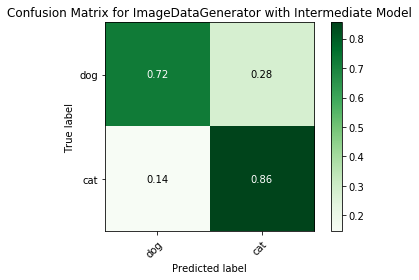

```python
#test_df['label'] = predictionsAugmented2

#test_df['label'] = np.where(test_df['label'] > 0.5, 1, 0)

plot_confusion_matrix(ground_truth, predictionsAugmented2, classes=['dog', 'cat'],title='Confusion Matrix for ImageDataGenerator with Intermediate Model')
```

## TRANSFER LEARNING

### VGG16

```python
from keras.applications import VGG16
```

```python
vgg_conv = VGG16(weights='imagenet',
                  include_top=False,
                  input_shape=(64, 64, 3))
```

```
Downloading data from https://github.com/fchollet/deep-learning-models/releases/download/v0.1/vgg16_weights_tf_dim_ordering_tf_kernels_notop.h5
```

```python
def get_pretrained(pretrained_model= vgg_conv, train=trainvectors, test=testvectors):

  features = pretrained_model.predict(trainvectors)

  features = np.reshape(features, (train.shape[0], features.shape[1]*features.shape[2]*features.shape[3]))

  featurestest=pretrained_model.predict(testvectors)

  featurestest = np.reshape(featurestest, (test.shape[0], featurestest.shape[1]*featurestest.shape[2]*featurestest.shape[3]))

  return features, featurestest
```

```python
features, featurestest = get_pretrained()
```

```python
def transfer_learning(n_dense=500, img_row=64, img_col=64, channels=3, dropout=0.4, features_extracted = features):


  model = Sequential()

  model.add(Dense(n_dense, activation='relu', input_dim=features.shape[1]))

  model.add(Dropout(dropout))

  model.add(Dense(n_dense, activation='relu'))

  model.add(Dropout(dropout))

  model.add(Dense(1, activation='sigmoid'))

  model.compile(loss='binary_crossentropy', optimizer='adam', metrics=['accuracy'])

  return model
```

```python
transfervgg16 = transfer_learning()
```

```python
es = EarlyStopping(monitor='val_loss', mode='min', patience=15, min_delta=0.01)

transfervgg16.fit(features, y_train, batch_size=128, verbose=2, callbacks=[lh, es], validation_split=0.15, epochs=100)
```

```
Train on 17005 samples, validate on 3001 samples
 - 3s - loss: 0.4956 - acc: 0.7587 - val_loss: 0.3891 - val_acc: 0.8241
 - 1s - loss: 0.4025 - acc: 0.8155 - val_loss: 0.3778 - val_acc: 0.8297
 - 1s - loss: 0.3772 - acc: 0.8294 - val_loss: 0.3658 - val_acc: 0.8367
 - 1s - loss: 0.3591 - acc: 0.8402 - val_loss: 0.3628 - val_acc: 0.8327
 - 1s - loss: 0.3445 - acc: 0.8455 - val_loss: 0.3698 - val_acc: 0.8261
 - 1s - loss: 0.3406 - acc: 0.8495 - val_loss: 0.3700 - val_acc: 0.8344
 - 1s - loss: 0.3162 - acc: 0.8618 - val_loss: 0.3665 - val_acc: 0.8424
 - 1s - loss: 0.3079 - acc: 0.8666 - val_loss: 0.3773 - val_acc: 0.8261
 - 1s - loss: 0.2898 - acc: 0.8721 - val_loss: 0.3665 - val_acc: 0.8317
 - 1s - loss: 0.2797 - acc: 0.8782 - val_loss: 0.3769 - val_acc: 0.8354
 - 1s - loss: 0.2633 - acc: 0.8851 - val_loss: 0.3973 - val_acc: 0.8357
 - 1s - loss: 0.2519 - acc: 0.8901 - val_loss: 0.3986 - val_acc: 0.8307
 - 1s - loss: 0.2384 - acc: 0.9010 - val_loss: 0.4234 - val_acc: 0.8281
 - 1s - loss: 0.2311 - acc: 0.9001 - val_loss: 0.4369 - val_acc: 0.8314
 - 1s - loss: 0.2155 - acc: 0.9082 - val_loss: 0.4195 - val_acc: 0.8374
 - 1s - loss: 0.2055 - acc: 0.9122 - val_loss: 0.4441 - val_acc: 0.8324
 - 1s - loss: 0.2031 - acc: 0.9138 - val_loss: 0.4464 - val_acc: 0.8197
 - 1s - loss: 0.2000 - acc: 0.9149 - val_loss: 0.4454 - val_acc: 0.8314
```

```
<keras.callbacks.History at 0x7ff225656550>
```

```python
transfervgg16.evaluate(featurestest, y_test)
```

```
[0.48740946336984636, 0.8206]
```

### Otras Alternativas: MEJOR MODELO

Otra forma que tenemos de hacer esto es introduciendo directamente en la red la red preentrenada, aunque es aconsejable seguir el procedimiento que mostramos previamente para adaptar una red a un problema de clasificación diferente (según hemos podido ver en los blogs de medium y github que hablan de esto). Vamos a probar con este segundo caso. Además, hemos visto que mucha gente para resolver problemas de este tipo también utiliza el optimizador RMSProp, por lo tanto vamos a probarlo también en este apartado. Adicionalmente, entrenaremos sobre los datos generados por ImageDataGenerator.

En este caso hemos probado sin reentrenar y entrenando las capas de la vgg16; dejamos aquí los resultados que más nos han convencido.

```python
from keras.applications import VGG16
conv_base = VGG16(weights='imagenet',
                  include_top=False,
                  input_shape=(64, 64, 3))

def alternative_transfer(n_dense=128, img_row=64, img_col=64, channels=3, dropout=0.4, conv_base=conv_base, last_not_trainable=15, max_depth=19, train=False):
  from keras import optimizers
  from keras.layers import Activation
  model = Sequential()
  model.add(conv_base)
  model.add(Flatten())
  model.add(Dropout(dropout/2))
  model.add(Dense(n_dense))
  model.add(Activation('relu'))
  model.add(Dropout(dropout))
  model.add(Dense(n_dense))
  model.add(Activation('relu'))
  model.add(Dropout(dropout))
  model.add(Dense(n_dense))
  model.add(Activation('relu'))
  model.add(Dropout(dropout))
  model.add(Dense(1, activation='sigmoid'))
  if not train:
    for i in range(0, last_not_trainable):
      conv_base.layers[i].trainable=False
    for i in range(last_not_trainable, max_depth):
      conv_base.layers[i].trainable=True
  else:
    for i in range(0, max_depth):
      conv_base.layers[i].trainable=True

  model.compile(loss='binary_crossentropy',
               optimizer=optimizers.RMSprop(lr=1e-5),
               metrics=['acc'])

  return model
```

```python
alt_trans = alternative_transfer(n_dense = 256, train=True, dropout=0.5)
lh = LossHistory()
es = EarlyStopping(monitor='val_loss', patience=5, mode='min')
lr_red = ReduceLROnPlateau(monitor='val_acc',
                           patience=1,
                           verbose=1,
                           factor=0.5,
                           min_lr=0.00001)

seed(69)

alt_trans_history = alt_trans.fit(trainvectors, y_train, epochs=100, validation_split=0.15, batch_size=128, verbose=2, callbacks=[lh, es, lr_red])
```

```
Train on 17005 samples, validate on 3001 samples
 - 25s - loss: 0.7511 - acc: 0.5347 - val_loss: 0.5925 - val_acc: 0.6981
 - 24s - loss: 0.5669 - acc: 0.7016 - val_loss: 0.3935 - val_acc: 0.8324
 - 24s - loss: 0.4356 - acc: 0.7985 - val_loss: 0.3112 - val_acc: 0.8687
 - 23s - loss: 0.3667 - acc: 0.8433 - val_loss: 0.2809 - val_acc: 0.8780
 - 24s - loss: 0.3149 - acc: 0.8710 - val_loss: 0.3162 - val_acc: 0.8637
 - 24s - loss: 0.2779 - acc: 0.8890 - val_loss: 0.2582 - val_acc: 0.8907
 - 24s - loss: 0.2449 - acc: 0.9031 - val_loss: 0.2442 - val_acc: 0.8980
 - 24s - loss: 0.2196 - acc: 0.9136 - val_loss: 0.2152 - val_acc: 0.9130
 - 24s - loss: 0.1947 - acc: 0.9244 - val_loss: 0.2870 - val_acc: 0.8937
 - 24s - loss: 0.1751 - acc: 0.9330 - val_loss: 0.2073 - val_acc: 0.9174
 - 24s - loss: 0.1562 - acc: 0.9397 - val_loss: 0.2242 - val_acc: 0.9220
 - 24s - loss: 0.1365 - acc: 0.9484 - val_loss: 0.2040 - val_acc: 0.9264
 - 24s - loss: 0.1181 - acc: 0.9569 - val_loss: 0.2386 - val_acc: 0.9234
 - 23s - loss: 0.1027 - acc: 0.9607 - val_loss: 0.4436 - val_acc: 0.8874
 - 23s - loss: 0.0886 - acc: 0.9694 - val_loss: 0.2296 - val_acc: 0.9260
 - 23s - loss: 0.0751 - acc: 0.9716 - val_loss: 0.3211 - val_acc: 0.9200
 - 23s - loss: 0.0688 - acc: 0.9759 - val_loss: 0.2443 - val_acc: 0.9277
```

```python
alt_trans.evaluate(testvectors, y_test)
```

```
[0.20878869129270314, 0.9362]
```

Como vemos, cuando reentrenamos la VGG16 que ponemos antes del resto de nuestra arquitectura si que mejoramos los resultados que hemos obtenido con el modelo intermedio; esto es a costa de un entrenamiento más largo, pero merece la pena pues obtenemos un accuracy ya superando claramente el 90%.

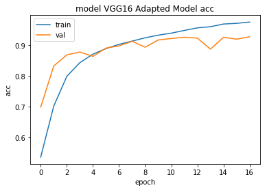

```python
plot_performance(history=alt_trans_history, name='VGG16 Adapted Model')
```

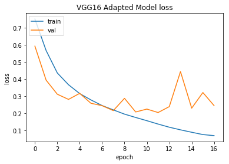

```python
plot_loss(history=alt_trans_history, name='VGG16 Adapted Model')
```

```
Normalized confusion matrix
[[0.9464 0.0536]
 [0.074  0.926 ]]
```

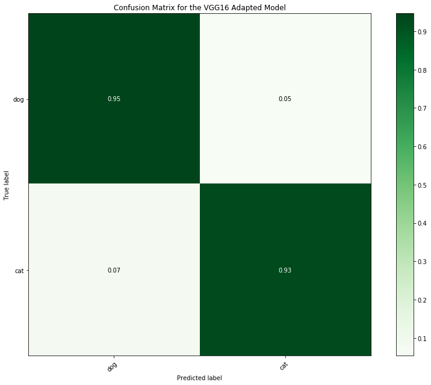

```python
plt.rcParams['figure.figsize'] = (12, 9)

plot_confusion_matrix(y_test, alt_trans.predict_classes(testvectors), classes=['dog', 'cat'], title='Confusion Matrix for the VGG16 Adapted Model')
```

### Lo mismo con Generador de Imágenes

```python
model=alternative_transfer()

history = model.fit_generator(
    train_generator,
    steps_per_epoch=100,
    epochs=100,
    validation_data=validation_generator,
    validation_steps=50,
    callbacks=[lh, es, lr_red])
```

Vemos que cuando utilizamos el generador de imágenes el modelo vgg16 no funciona tan bien. Es cierto que no hemos hecho simultáneamente el entrenador con imágenes generadas y el entrenamiento de las capas de vgg16 (en este segundo caso no las hemos dejado entrenarse), por el tiempo de cómputo que llevaría. Quizás si hiciéramos ambas cosas simultáneamente fuéramos capaces de llegar a un accuracy algo mayor, pero no rascaremos esos decimales por el tiempo de computación necesario.

```python
model.evaluate(testvectors, y_test)
```

```
[0.32105852336883545, 0.8614]
```

```python
from keras.applications import ResNet50
```

```python
resnet = ResNet50(weights='imagenet',
                  include_top=False,
                  input_shape=(64, 64, 3))

features, featurestest=get_pretrained(pretrained_model=resnet)
```

```
Downloading data from https://github.com/fchollet/deep-learning-models/releases/download/v0.2/resnet50_weights_tf_dim_ordering_tf_kernels_notop.h5
```

```python
transferResnet = transfer_learning(n_dense = 1000, features_extracted = features, dropout=0.5)
```

```python
transferResnet.fit(features, y_train, batch_size=128, verbose=2, callbacks=[lh, es], validation_split=0.15, epochs=100)
```

```
Train on 17005 samples, validate on 3001 samples
 - 5s - loss: 0.7018 - acc: 0.5554 - val_loss: 0.6509 - val_acc: 0.6128
 - 2s - loss: 0.6532 - acc: 0.6150 - val_loss: 0.6319 - val_acc: 0.6498
 - 2s - loss: 0.6491 - acc: 0.6197 - val_loss: 0.6378 - val_acc: 0.6415
 - 2s - loss: 0.6430 - acc: 0.6266 - val_loss: 0.6428 - val_acc: 0.6351
 - 2s - loss: 0.6403 - acc: 0.6285 - val_loss: 0.6184 - val_acc: 0.6568
 - 2s - loss: 0.6384 - acc: 0.6233 - val_loss: 0.6312 - val_acc: 0.6591
 - 2s - loss: 0.6398 - acc: 0.6237 - val_loss: 0.6207 - val_acc: 0.6654
 - 2s - loss: 0.6419 - acc: 0.6193 - val_loss: 0.6228 - val_acc: 0.6684
 - 2s - loss: 0.6381 - acc: 0.6289 - val_loss: 0.6196 - val_acc: 0.6701
 - 2s - loss: 0.6305 - acc: 0.6360 - val_loss: 0.6186 - val_acc: 0.6674
 - 2s - loss: 0.6259 - acc: 0.6412 - val_loss: 0.6234 - val_acc: 0.6664
 - 2s - loss: 0.6249 - acc: 0.6361 - val_loss: 0.6287 - val_acc: 0.6668
 - 2s - loss: 0.6328 - acc: 0.6248 - val_loss: 0.6472 - val_acc: 0.6208
 - 2s - loss: 0.6300 - acc: 0.6256 - val_loss: 0.6186 - val_acc: 0.6634
 - 2s - loss: 0.6280 - acc: 0.6284 - val_loss: 0.6124 - val_acc: 0.6704
 - 2s - loss: 0.6220 - acc: 0.6443 - val_loss: 0.6093 - val_acc: 0.6768
 - 2s - loss: 0.6226 - acc: 0.6327 - val_loss: 0.6171 - val_acc: 0.6714
 - 2s - loss: 0.6187 - acc: 0.6481 - val_loss: 0.6185 - val_acc: 0.6828
 - 2s - loss: 0.6300 - acc: 0.6265 - val_loss: 0.6184 - val_acc: 0.6771
 - 2s - loss: 0.6265 - acc: 0.6375 - val_loss: 0.6179 - val_acc: 0.6741
```

```
<keras.callbacks.History at 0x7ff1567fc400>
```

```python
transferResnet.evaluate(featurestest, y_test)
```

```
[0.6146677225112915, 0.6706]
```

El resultado en este segundo caso ha sido incluso peor que utilizando VGG16 (en el primero de los ejemplos, en el que usamos la función alternative_transfer sí funcionaba bien), por lo tanto ni vamos a volver a ejecutar el código para presentarlo (por el tiempo de cómputo). Es otro ejemplo de cosillas que dejamos simplemente para que queden programadas para quien quiera probarlo, pero que son una muestra de lo que **no funciona** para resolver este problema.

### VGG19

En este caso vamos a ver que los resultados son malísimos; le incluimos simplemente una capa de Dense después de la arquitectura de vgg19+flatten(), y con esto le es insuficiente al modelo para aprender a distinguir unos patrones de otros; no aprende prácticamente nada. No hemos puesto tanto esfuerzo en conseguir que este modelo aprenda porque con el vgg16 que vimos antes, dejándole entrenar en todas las capas y añadiéndole unas cuantas capas Dense después de la arquitectura de vgg16, ya obteníamos resultados muy buenos y el entrenamiento de estos modelos requiere tiempos de cómputo excesivos.

```python
from keras import applications

vgg19 = applications.VGG19(weights='imagenet',
                               include_top=False,
                               pooling=None,
                               input_shape=(64, 64, 3))

from keras import layers
from keras import models
model = Sequential()
model.add(vgg19)
model.add(Flatten())
model.add(Dense(256, activation  = 'relu'))
model.add(Dense(1, activation = 'sigmoid'))
model.compile(loss='binary_crossentropy',optimizer='adam',metrics=['acc'])
```

```
Downloading data from https://github.com/fchollet/deep-learning-models/releases/download/v0.1/vgg19_weights_tf_dim_ordering_tf_kernels_notop.h5
```

```python
model.fit(trainvectors, y_train, batch_size=128, verbose=2, callbacks=[lh, es], validation_split=0.15, epochs=100)
```

```
Train on 17005 samples, validate on 3001 samples
 - 38s - loss: 8.0154 - acc: 0.4995 - val_loss: 7.9597 - val_acc: 0.5062
 - 26s - loss: 8.0737 - acc: 0.4991 - val_loss: 7.9597 - val_acc: 0.5062
 - 26s - loss: 8.0737 - acc: 0.4991 - val_loss: 7.9597 - val_acc: 0.5062
 - 26s - loss: 8.0737 - acc: 0.4991 - val_loss: 7.9597 - val_acc: 0.5062
 - 27s - loss: 8.0737 - acc: 0.4991 - val_loss: 7.9597 - val_acc: 0.5062
 - 26s - loss: 8.0737 - acc: 0.4991 - val_loss: 7.9597 - val_acc: 0.5062
 - 26s - loss: 8.0737 - acc: 0.4991 - val_loss: 7.9597 - val_acc: 0.5062
 - 26s - loss: 8.0737 - acc: 0.4991 - val_loss: 7.9597 - val_acc: 0.5062
 - 26s - loss: 8.0737 - acc: 0.4991 - val_loss: 7.9597 - val_acc: 0.5062
 - 26s - loss: 8.0737 - acc: 0.4991 - val_loss: 7.9597 - val_acc: 0.5062
 - 26s - loss: 8.0737 - acc: 0.4991 - val_loss: 7.9597 - val_acc: 0.5062
 - 26s - loss: 8.0737 - acc: 0.4991 - val_loss: 7.9597 - val_acc: 0.5062
 - 26s - loss: 8.0737 - acc: 0.4991 - val_loss: 7.9597 - val_acc: 0.5062
 - 26s - loss: 8.0737 - acc: 0.4991 - val_loss: 7.9597 - val_acc: 0.5062
 - 26s - loss: 8.0737 - acc: 0.4991 - val_loss: 7.9597 - val_acc: 0.5062
 - 26s - loss: 8.0737 - acc: 0.4991 - val_loss: 7.9597 - val_acc: 0.5062
```

```
<keras.callbacks.History at 0x7ff15635a320>
```

```python
model.evaluate(testvectors, y_test)
```

```
[8.059047787475587, 0.5]
```

## ÚLTIMOS INTENTOS DE MEJORA

## Analyzing the results

```python
def deeper_model(n_dense=496, img_rows=64, img_cols=64, channels=3, kernel_size=4, pool_size=2, dropout=0.5):
  from keras.layers import ZeroPadding2D
  model = Sequential()
  model.add(ZeroPadding2D((1,1)))
  model.add(Convolution2D(32, # Number convolution channels to generate
                        (kernel_size, kernel_size), # Size of convolution kernels
                        padding='same', # Strategy to deal with borders
                        input_shape=(img_rows, img_cols, channels),
                         activation="relu"))
  model.add(ZeroPadding2D((1,1)))

  model.add(BatchNormalization())

  model.add(MaxPooling2D(pool_size=(pool_size, pool_size), strides=2))
  model.add(Dropout(dropout/2))

  model.add(Convolution2D(32,
                         (kernel_size, kernel_size),
                         padding='same',
                         activation='relu'))
  model.add(ZeroPadding2D((1,1)))
  model.add(BatchNormalization())
  model.add(MaxPooling2D(pool_size=(pool_size, pool_size), strides=2))
  model.add(Dropout(dropout/2))

  model.add(Convolution2D(64,
                         (kernel_size, kernel_size),
                         padding='same',
                         activation='relu'))
  model.add(ZeroPadding2D((1,1)))
  model.add(BatchNormalization())
  model.add(MaxPooling2D(pool_size=(pool_size, pool_size),strides=2))
  model.add(Dropout(dropout/2))

  model.add(Convolution2D(64, (kernel_size, kernel_size), padding='same', activation='relu'))
  model.add(ZeroPadding2D((1,1)))
  model.add(BatchNormalization())
  model.add(MaxPooling2D(pool_size=(pool_size, pool_size), strides=2))
  model.add(Dropout(dropout/2))

  model.add(Convolution2D(128, (kernel_size, kernel_size), padding='same', activation='relu'))
  model.add(Convolution2D(128, (kernel_size, kernel_size), padding='same', activation='relu'))
  model.add(ZeroPadding2D((1,1)))
  model.add(BatchNormalization())
  model.add(MaxPooling2D(pool_size=(pool_size, pool_size), strides=2))

  model.add(Flatten())
  model.add(Dropout(dropout))

  model.add(Dense(n_dense, activation='relu'))
  model.add(Dropout(dropout))

  model.add(BatchNormalization())

  model.add(Dense(n_dense, activation='relu'))
  model.add(Dropout(dropout))

  model.add(Dense(1, activation="sigmoid"))

  model.compile(loss='binary_crossentropy', optimizer='adam', metrics=['accuracy'])

  return model
```

```python
deeper = deeper_model()
historyDeeper=deeper.fit(trainvectors, np.array(y_train), batch_size=128, verbose=2, callbacks=[lh, es, lr_red], validation_split=0.15, epochs=100)
```

```
Train on 17005 samples, validate on 3001 samples
 - 12s - loss: 0.7572 - acc: 0.5638 - val_loss: 0.6818 - val_acc: 0.6311
 - 7s - loss: 0.6494 - acc: 0.6288 - val_loss: 0.6477 - val_acc: 0.6648
 - 7s - loss: 0.5863 - acc: 0.6856 - val_loss: 0.6470 - val_acc: 0.7068
 - 7s - loss: 0.5266 - acc: 0.7347 - val_loss: 0.5245 - val_acc: 0.7557
 - 7s - loss: 0.4776 - acc: 0.7670 - val_loss: 0.4471 - val_acc: 0.8064
 - 7s - loss: 0.4296 - acc: 0.8008 - val_loss: 0.4640 - val_acc: 0.7677
 - 7s - loss: 0.4031 - acc: 0.8141 - val_loss: 0.5783 - val_acc: 0.7701

Epoch 00007: ReduceLROnPlateau reducing learning rate to 0.0005000000237487257.
 - 7s - loss: 0.3559 - acc: 0.8430 - val_loss: 0.3544 - val_acc: 0.8404
 - 7s - loss: 0.3310 - acc: 0.8546 - val_loss: 0.3364 - val_acc: 0.8494
 - 7s - loss: 0.3136 - acc: 0.8610 - val_loss: 0.3221 - val_acc: 0.8637
 - 7s - loss: 0.2993 - acc: 0.8699 - val_loss: 0.3213 - val_acc: 0.8674
 - 7s - loss: 0.2916 - acc: 0.8717 - val_loss: 0.3280 - val_acc: 0.8567
 - 7s - loss: 0.2792 - acc: 0.8820 - val_loss: 0.3278 - val_acc: 0.8560

Epoch 00013: ReduceLROnPlateau reducing learning rate to 0.0002500000118743628.
 - 7s - loss: 0.2543 - acc: 0.8922 - val_loss: 0.3065 - val_acc: 0.8730
 - 7s - loss: 0.2419 - acc: 0.9004 - val_loss: 0.2922 - val_acc: 0.8767
 - 7s - loss: 0.2402 - acc: 0.8983 - val_loss: 0.3022 - val_acc: 0.8690
 - 7s - loss: 0.2274 - acc: 0.9027 - val_loss: 0.2926 - val_acc: 0.8724

Epoch 00017: ReduceLROnPlateau reducing learning rate to 0.0001250000059371814.
 - 7s - loss: 0.2147 - acc: 0.9085 - val_loss: 0.2825 - val_acc: 0.8850
 - 7s - loss: 0.2076 - acc: 0.9134 - val_loss: 0.2816 - val_acc: 0.8824
 - 7s - loss: 0.2056 - acc: 0.9145 - val_loss: 0.2833 - val_acc: 0.8790

Epoch 00020: ReduceLROnPlateau reducing learning rate to 6.25000029685907e-05.
 - 7s - loss: 0.1914 - acc: 0.9213 - val_loss: 0.2747 - val_acc: 0.8877
 - 7s - loss: 0.1918 - acc: 0.9194 - val_loss: 0.2741 - val_acc: 0.8894
 - 7s - loss: 0.1945 - acc: 0.9198 - val_loss: 0.2807 - val_acc: 0.8860
 - 7s - loss: 0.1870 - acc: 0.9230 - val_loss: 0.2828 - val_acc: 0.8834

Epoch 00024: ReduceLROnPlateau reducing learning rate to 3.125000148429535e-05.
 - 7s - loss: 0.1820 - acc: 0.9258 - val_loss: 0.2812 - val_acc: 0.8894
 - 7s - loss: 0.1827 - acc: 0.9249 - val_loss: 0.2810 - val_acc: 0.8874

Epoch 00026: ReduceLROnPlateau reducing learning rate to 1.5625000742147677e-05.
 - 7s - loss: 0.1783 - acc: 0.9287 - val_loss: 0.2796 - val_acc: 0.8867
 - 7s - loss: 0.1795 - acc: 0.9270 - val_loss: 0.2796 - val_acc: 0.8887

Epoch 00028: ReduceLROnPlateau reducing learning rate to 1e-05.
 - 7s - loss: 0.1850 - acc: 0.9223 - val_loss: 0.2825 - val_acc: 0.8857
 - 7s - loss: 0.1820 - acc: 0.9268 - val_loss: 0.2824 - val_acc: 0.8867
 - 7s - loss: 0.1753 - acc: 0.9281 - val_loss: 0.2815 - val_acc: 0.8870
 - 7s - loss: 0.1799 - acc: 0.9263 - val_loss: 0.2804 - val_acc: 0.8897
 - 7s - loss: 0.1789 - acc: 0.9265 - val_loss: 0.2807 - val_acc: 0.8900
 - 7s - loss: 0.1683 - acc: 0.9308 - val_loss: 0.2813 - val_acc: 0.8864
```

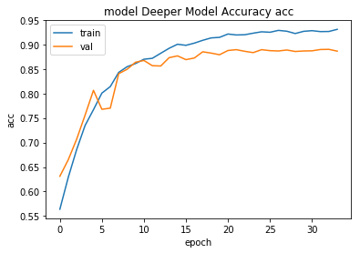

```python
plot_performance(history=historyDeeper, name='Deeper Model Accuracy')
```

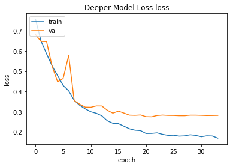

```python
plot_loss(history=historyDeeper, name='Deeper Model Loss')
```

```
Normalized confusion matrix
[[0.8856 0.1144]
 [0.1016 0.8984]]
```

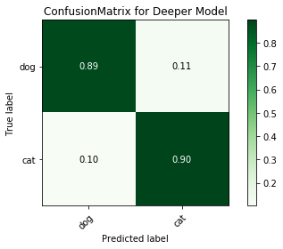

```python
predsDeep = deeper.predict_classes(testvectors)
plot_confusion_matrix(y_test, predsDeep, classes=['dog', 'cat'], title='ConfusionMatrix for Deeper Model')
```

```python
deeper.evaluate(testvectors, y_test)
```

```
[0.28330195860862734, 0.892]
```

Vemos que el modelo más profundo tampoco supera de forma significativa al modelo intermedio.

Find and show some test images for which your model fails. Can you give an explanation for this behavior?

```python
####### INSERT YOUR CODE HERE

def get_failed_predictions(y_true, preds, nombre):
  i_falladas = [ i for i in range(len(preds)) if preds[i] != y_true[i]]

  # Número de imágenes mal categorizadas
  print('El modelo {} ha fallado en {} casos, es decir un porcentaje de {}'.format(nombre, len(i_falladas), len(i_falladas)/len(y_true)))

  ejemplos = i_falladas[:10]

  fig=plt.figure(figsize=(12, 9))
  plt.title('Examples of Failed Images')
  columns = 5
  rows = 2
  for i in range(1, columns*rows +1):
      img = testvectors[i]+0.5
      fig.add_subplot(rows, columns, i)
      plt.imshow(img)
  plt.show()
```